```python
# !pip install matplotlib pandas transformers seaborn
```

# Проект по анализу данных "Зависимость результатов multiple-choice классификации от семантической близости классов"

## Гипотеза

H0: Семантическая близость классов обратно пропорциональна precision LLM классификатора.

H1: Семантическая близость классов пропорциональна precision LLM классификатора.

## Данные

Данные взяты из бенчмарка дискурсивных явлений [DISRP](https://aclanthology.org/2024.lrec-main.447/) (русскоязычный сабсет). Перед моделью стоит задача классификации дискурсивных отношений между предложениями (частями предложений). Всего в датасете 22 класса. Для сравнения семантической близости классов использовался bge-small-en-v1.5.

## Методология

```python
import json
import random
import numpy as np
import pandas as pd
from tqdm import tqdm
from transformers import pipeline
from sklearn.cluster import KMeans
from sklearn.manifold import TSNE
from sklearn.preprocessing import normalize
from sklearn.metrics.pairwise import cosine_similarity
from sklearn.metrics import (
    accuracy_score,
    precision_recall_fscore_support,
    confusion_matrix,
    classification_report,
)
import matplotlib.pyplot as plt
import seaborn as sns
from scipy.stats import pearsonr
```

## Data loading

```python
with open("full_disrpt.json", "r", encoding="utf-8") as f:
    data = json.load(f)

# embedder = pipeline("feature-extraction", model="DeepPavlov/rubert-base-cased")
# embedder = pipeline("feature-extraction", model="cointegrated/LaBSE-en-ru")

embedder = pipeline("feature-extraction", model="BAAI/bge-small-en-v1.5")


def get_embedding(text):
    """
    Get the embedding for a given text using the embedder pipeline.
    """
    embedding = embedder(text)
    return np.mean(embedding[0], axis=0)
```

```
Device set to use cuda:0
```

```python
df = pd.DataFrame(columns=["start", "end", "label"])
for item in data.values():
    row = {
        # '_id': item['id'],
        "start": item["sent_1"],
        "end": item["sent_2"],
        "label": item["label"],
    }
    df.loc[-1] = row
    df.index = df.index + 1
df.head()
```

|  | start | end | label |
| --- | --- | --- | --- |
| 28867 | - формируются коэффициенты модулей начальной и... | [ формула ] ; | elaboration |
| 28866 | В этой статье решено привести обобщение алгори... | которые могут быть описаны одной или нескольки... | elaboration |
| 28865 | Кабардинец везёт хлеб | - едет в Подольск , | joint |
| 28864 | ##### — Какие именно из всего семейства лиценз... | ##### — Проекты фонда « Викимедиа » , лицензир... | solutionhood |
| 28863 | Помимо правильного рабочего места , о котором ... | Регулярное выполнение асан поможет сохранить з... | elaboration |

```python
df.info()
```

```
<class 'pandas.core.frame.DataFrame'>
Index: 28868 entries, 28867 to 0
Data columns (total 3 columns):
 #   Column  Non-Null Count  Dtype
---  ------  --------------  -----
 0   start   28868 non-null  object
 1   end     28868 non-null  object
 2   label   28868 non-null  object
dtypes: object(3)
memory usage: 902.1+ KB
```

```python
labels = df["label"].unique()
print(f"{len(labels)} Labels: {labels}")
```

```
22 Labels: ['elaboration' 'joint' 'solutionhood' 'cause' 'contrast' 'sequence'
 'purpose' 'preparation' 'concession' 'restatement' 'attribution'
 'evidence' 'evaluation' 'condition' 'background' 'cause-effect'
 'comparison' 'interpretation-evaluation' 'effect' 'antithesis'
 'conclusion' 'motivation']
```

```
<BarContainer object of 22 artists>
```

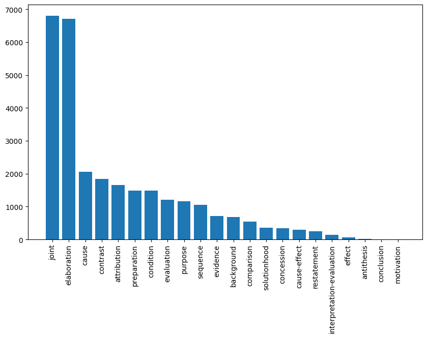

```python
plt.figure(figsize=(10, 6))
labels_amount = df["label"].value_counts()
plt.xticks(rotation=90)
plt.bar(labels_amount.index, labels_amount.values)
```

Как можно заметить, дисбаланс классов в датасете достаточно большой, однако, для наших целей это не критично, т.к. мы не будем ничего обучать, а просто посмотрим на то, как ведут себя модели с различной комбинацией вариантов ответа. Всё же, нам нужно будет выделить сабсет учитывающий дисбаланс классов.

```python
# Create a test set for scoring
test_set = df.sample(frac=0.05, random_state=1)
print(f"Test set size: {len(test_set)}")
print(f"{len(test_set['label'].unique())} labels in the test set")
print(test_set["label"].value_counts())
```

```
Test set size: 1443
21 labels in the test set
label
joint                        332
elaboration                  317
contrast                     107
cause                         99
attribution                   90
condition                     76
preparation                   65
evaluation                    59
purpose                       57
sequence                      54
background                    45
evidence                      38
comparison                    29
concession                    18
solutionhood                  14
interpretation-evaluation     12
cause-effect                  11
restatement                   11
antithesis                     5
effect                         3
motivation                     1
Name: count, dtype: int64
```

```python
test_set.head()
```

|  | start | end | label |
| --- | --- | --- | --- |
| 28831 | Дочь вышла замуж за некоего Гуарама , | Их первенец Баграт дал имя одному из самых изв... | cause |
| 14161 | 1 ) разной степени специализации фонемных приз... | 3 ) разной вариативности и количества артикуля... | joint |
| 25900 | чтобы выбрать наиболее эффективный | при разных трудозатратах . | condition |
| 21208 | " Ты , и только ты единственный/единственная ,... | Да , в обмен на эту связь и ощущение безопасно... | evaluation |
| 15591 | Нельзя сказать , что реальным сеньорам известн... | Они , скорее , отличаются особой структурой зн... | contrast |

## Similar or contrasting labels

Теперь мы можем попробовать найти для каждого класса наиболее и наименее похожие на него классы. Для этого мы используем сравнение векторов классов -- мы можем сравнить эмбеддинги названий классов и найти наиболее похожие и непохожие классы по косинусной близости.

```python
label_embeddings = []
for label in labels:
    embedding = get_embedding(label)
    label_embeddings.append({"label": label, "embedding": embedding})

labels_emb_df = pd.DataFrame(label_embeddings)
labels_emb_df.to_csv("label_embeddings_rubert.csv", index=False)
```

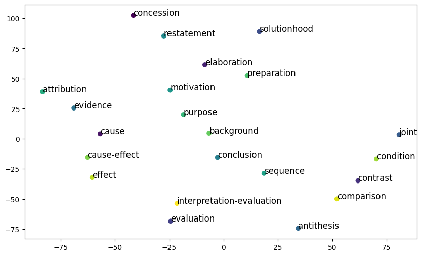

```python
# Clustering labels
label_embeddings = np.array(labels_emb_df["embedding"].tolist())
label_embeddings = normalize(label_embeddings)

k = len(labels)  # Number of clusters equal to number of unique labels
kmeans = KMeans(n_clusters=k, random_state=42).fit(label_embeddings)

# Reduce dimensions for visualization
tsne = TSNE(n_components=2, random_state=42, perplexity=5)
label_embeddings = tsne.fit_transform(label_embeddings)

# Plotting the clusters with names
plt.figure(figsize=(10, 6))
for i, label in enumerate(labels):
    plt.annotate(label, (label_embeddings[i, 0], label_embeddings[i, 1]), fontsize=12)
plt.scatter(
    label_embeddings[:, 0],
    label_embeddings[:, 1],
    c=kmeans.labels_,
    cmap="viridis",
    marker="o",
)
```

```python
# Get top 4 closest labels to each label and top 4 furthest labels by cosine similarity

labels_dictionaty = {}
cos_sim_matrix = cosine_similarity(label_embeddings, label_embeddings)
for i, label in enumerate(labels):
    # Exclude the label itself by setting its similarity to -inf/+inf
    sim_scores = cos_sim_matrix[i].copy()
    sim_scores[i] = -np.inf  # for closest
    closest_idx = np.argsort(sim_scores)[-4:][::-1]
    sim_scores[i] = np.inf  # for furthest
    furthest_idx = np.argsort(sim_scores)[:4]
    labels_dictionaty[label] = {
        "closest": labels[closest_idx].tolist(),
        "furthest": labels[furthest_idx].tolist(),
    }
for label, values in labels_dictionaty.items():
    print(f"Label: {label}")
    print(f"  Closest: {values['closest']}")
    print(f"  Furthest: {values['furthest']}")
```

```
Label: elaboration
  Closest: ['restatement', 'concession', 'solutionhood', 'preparation']
  Furthest: ['antithesis', 'conclusion', 'sequence', 'evaluation']
Label: joint
  Closest: ['condition', 'contrast', 'comparison', 'sequence']
  Furthest: ['cause', 'cause-effect', 'evidence', 'effect']
Label: solutionhood
  Closest: ['preparation', 'elaboration', 'restatement', 'concession']
  Furthest: ['conclusion', 'evaluation', 'interpretation-evaluation', 'antithesis']
Label: cause
  Closest: ['evidence', 'cause-effect', 'attribution', 'background']
  Furthest: ['joint', 'condition', 'contrast', 'comparison']
Label: contrast
  Closest: ['comparison', 'condition', 'sequence', 'joint']
  Furthest: ['attribution', 'background', 'evidence', 'purpose']
Label: sequence
  Closest: ['antithesis', 'comparison', 'contrast', 'conclusion']
  Furthest: ['motivation', 'purpose', 'concession', 'restatement']
Label: purpose
  Closest: ['motivation', 'background', 'concession', 'attribution']
  Furthest: ['comparison', 'sequence', 'antithesis', 'contrast']
Label: preparation
  Closest: ['solutionhood', 'elaboration', 'restatement', 'concession']
  Furthest: ['conclusion', 'evaluation', 'interpretation-evaluation', 'antithesis']
Label: concession
  Closest: ['restatement', 'motivation', 'elaboration', 'purpose']
  Furthest: ['antithesis', 'sequence', 'comparison', 'conclusion']
Label: restatement
  Closest: ['concession', 'elaboration', 'motivation', 'purpose']
  Furthest: ['antithesis', 'sequence', 'conclusion', 'comparison']
Label: attribution
  Closest: ['evidence', 'background', 'cause', 'purpose']
  Furthest: ['contrast', 'condition', 'comparison', 'joint']
Label: evidence
  Closest: ['attribution', 'background', 'cause', 'purpose']
  Furthest: ['condition', 'contrast', 'joint', 'comparison']
Label: evaluation
  Closest: ['interpretation-evaluation', 'conclusion', 'effect', 'antithesis']
  Furthest: ['preparation', 'solutionhood', 'elaboration', 'restatement']
Label: condition
```

[output cut: 11 more lines]

```
Label: interpretation-evaluation
  Closest: ['evaluation', 'conclusion', 'effect', 'antithesis']
  Furthest: ['preparation', 'solutionhood', 'elaboration', 'restatement']
Label: effect
  Closest: ['cause-effect', 'cause', 'interpretation-evaluation', 'evaluation']
  Furthest: ['joint', 'condition', 'preparation', 'solutionhood']
Label: antithesis
  Closest: ['sequence', 'comparison', 'conclusion', 'contrast']
  Furthest: ['concession', 'motivation', 'restatement', 'elaboration']
Label: conclusion
  Closest: ['evaluation', 'interpretation-evaluation', 'antithesis', 'sequence']
  Furthest: ['solutionhood', 'preparation', 'elaboration', 'restatement']
Label: motivation
  Closest: ['concession', 'purpose', 'restatement', 'elaboration']
  Furthest: ['sequence', 'antithesis', 'comparison', 'contrast']
```

Добавим в датасет столбцы с наиболее похожими и непохожими классами.

```python
test_set["closest"] = test_set["label"].map(lambda x: labels_dictionaty[x]["closest"])
test_set["furthest"] = test_set["label"].map(lambda x: labels_dictionaty[x]["furthest"])
test_set["random"] = test_set["label"].map(
    lambda x: np.random.choice(
        test_set["label"].unique().tolist(), 4, replace=False
    ).tolist()
)
test_set["all"] = test_set["label"].map(lambda x: test_set["label"].unique().tolist())
test_set.head()
```

|  | start | end | label | closest | furthest | random | all |
| --- | --- | --- | --- | --- | --- | --- | --- |
| 28831 | Дочь вышла замуж за некоего Гуарама , | Их первенец Баграт дал имя одному из самых изв... | cause | [evidence, cause-effect, attribution, background] | [joint, condition, contrast, comparison] | [interpretation-evaluation, background, restat... | [cause, joint, condition, evaluation, contrast... |
| 14161 | 1 ) разной степени специализации фонемных приз... | 3 ) разной вариативности и количества артикуля... | joint | [condition, contrast, comparison, sequence] | [cause, cause-effect, evidence, effect] | [elaboration, attribution, concession, motivat... | [cause, joint, condition, evaluation, contrast... |
| 25900 | чтобы выбрать наиболее эффективный | при разных трудозатратах . | condition | [joint, contrast, comparison, sequence] | [evidence, cause, attribution, background] | [attribution, restatement, preparation, joint] | [cause, joint, condition, evaluation, contrast... |
| 21208 | " Ты , и только ты единственный/единственная ,... | Да , в обмен на эту связь и ощущение безопасно... | evaluation | [interpretation-evaluation, conclusion, effect... | [preparation, solutionhood, elaboration, resta... | [condition, motivation, evidence, solutionhood] | [cause, joint, condition, evaluation, contrast... |
| 15591 | Нельзя сказать , что реальным сеньорам известн... | Они , скорее , отличаются особой структурой зн... | contrast | [comparison, condition, sequence, joint] | [attribution, background, evidence, purpose] | [evaluation, antithesis, background, interpret... | [cause, joint, condition, evaluation, contrast... |

```python
label_to_emb = {row['label']: np.array(row['embedding']) for _, row in labels_emb_df.iterrows()}

def avg_cosine_sim(col_name):
    sims = []
    for _, row in test_set.iterrows():
        label_emb = label_to_emb[row['label']]
        # Calculate average embedding for the choices
        choices_emb = np.mean([label_to_emb[choice] for choice in row[col_name]], axis=0)

        sim = cosine_similarity([label_emb], [choices_emb])[0][0]
        sims.append(sim)
    return np.mean(sims)

similarities = {}

for col in ["closest", "furthest", "random", "all"]:
    avg_sim = avg_cosine_sim(col)
    similarities[col] = avg_sim
    # print(f"Average cosine similarity for '{col}': {avg_sim:.4f}")
similarities_df = pd.DataFrame.from_dict(similarities, orient='index', columns=['Average Cosine Similarity'])
similarities_df.head()
```

|  | Average Cosine Similarity |
| --- | --- |
| closest | 0.716062 |
| furthest | 0.645864 |
| random | 0.706171 |
| all | 0.759086 |

## Scoring

for this part to run you need to have `.env` file with `OPENAI_API_KEY` and `OPENAI_BASE_URL` set.

```python
from score_model import score_disrpt
```

```python
# Посчитаем метрики для тестового набора с разными вариантами вариантов ответа
closest_set = test_set[["start", "end", "label", "closest"]].copy()
closest_set.rename(columns={"closest": "choices"}, inplace=True)
score_disrpt(
    model_name="gpt-4o-mini",
    temperature=0.5,
    test_set=closest_set,
    filename="gpt4o_mini_closest.csv",
)
```

```
[INFO] Starting disrpt scoring...
```

```
[INFO] Disrpt scoring complete. Results saved to: gpt4o_mini_closest.csv
```

```
({'accuracy': 0.46084546084546085,
  'recall': 0.36778899134802506,
  'f1': 0.2978047815372343,
  'precision': 0.3438929547918048},
 'gpt4o_mini_closest.csv')
```

```python
furthest_set = test_set[["start", "end", "label", "furthest"]].copy()
furthest_set.rename(columns={"furthest": "choices"}, inplace=True)
score_disrpt(
    model_name="gpt-4o-mini",
    temperature=0.5,
    test_set=furthest_set,
    filename="gpt4o_mini_furthest.csv",
)
```

```
[INFO] Starting disrpt scoring...
```

```
[INFO] Disrpt scoring complete. Results saved to: gpt4o_mini_furthest.csv
```

```
({'accuracy': 0.5904365904365905,
  'recall': 0.5801491793721999,
  'f1': 0.5071356889718956,
  'precision': 0.534008908567364},
 'gpt4o_mini_furthest.csv')
```

```python
random_set = test_set[["start", "end", "label", "random"]].copy()
random_set.rename(columns={"random": "choices"}, inplace=True)
score_disrpt(
    model_name="gpt-4o-mini",
    temperature=0.5,
    test_set=random_set,
    filename="gpt4o_mini_random.csv",
)
```

```
[INFO] Starting disrpt scoring...
```

```
[INFO] Disrpt scoring complete. Results saved to: gpt4o_mini_random.csv
```

```
({'accuracy': 0.483021483021483,
  'recall': 0.45412073944699666,
  'f1': 0.36052196556609817,
  'precision': 0.37058395331095284},
 'gpt4o_mini_random.csv')
```

```python
all_set = test_set[["start", "end", "label", "all"]].copy()
all_set.rename(columns={"all": "choices"}, inplace=True)
score_disrpt(
    model_name="gpt-4o-mini",
    temperature=0.5,
    test_set=all_set,
    filename="gpt4o_mini_all.csv",
)
```

```
[INFO] Starting disrpt scoring...
```

```
[INFO] Disrpt scoring complete. Results saved to: gpt4o_mini_all.csv
```

```
({'accuracy': 0.2945252945252945,
  'recall': 0.25364636118067724,
  'f1': 0.2166693633584598,
  'precision': 0.26670081557635805},
 'gpt4o_mini_all.csv')
```

## Analyzing results

Теперь мы можем проанализировать результаты, которые мы получили. В первую очередь, мы можем посмотреть на confusion matrix, чтобы понять, какие классы чаще всего путаются между собой. А также мы можем посмотреть на корреляцию accuracy и сабсета.

```python
similar_labels_df = pd.read_csv("gpt4o_mini_closest.csv")
different_labels_df = pd.read_csv("gpt4o_mini_furthest.csv")
random_labels_df = pd.read_csv("gpt4o_mini_random.csv")
all_labels_df = pd.read_csv("gpt4o_mini_all.csv")
```

### Случайный набор классов

```
Accuracy: 0.4830
Macro Precision: 0.3706
Macro Recall: 0.4541
Macro F1: 0.3605
```

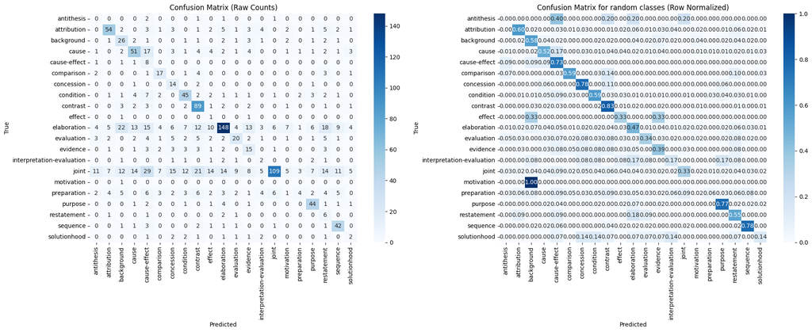

```python
y_true = random_labels_df["correct_answer"].values
y_pred = random_labels_df["answer"].values

# Calculate accuracy
accuracy = accuracy_score(y_true, y_pred)
print(f"Accuracy: {accuracy:.4f}")

# Get unique labels (relations)
labels = sorted(list(set(y_true) | set(y_pred)))

precision, recall, f1, _ = precision_recall_fscore_support(
    y_true, y_pred, average="macro", labels=labels
)
print(f"Macro Precision: {precision:.4f}")
print(f"Macro Recall: {recall:.4f}")
print(f"Macro F1: {f1:.4f}")

# Create figure with two subplots side by side
fig, (ax1, ax2) = plt.subplots(1, 2, figsize=(20, 8))

# 1. Regular confusion matrix
cm = confusion_matrix(y_true, y_pred, labels=labels)
sns.heatmap(
    cm,
    annot=True,
    fmt="d",
    cmap="Blues",
    xticklabels=labels,
    yticklabels=labels,
    ax=ax1,
)
ax1.set_xlabel("Predicted")
ax1.set_ylabel("True")
ax1.set_title("Confusion Matrix (Raw Counts)")

# 2. Row-normalized confusion matrix (normalize by true label)
cm_normalized = confusion_matrix(y_true, y_pred, labels=labels, normalize="true")
sns.heatmap(
    cm_normalized,
    annot=True,
    fmt=".2f",
    cmap="Blues",
    xticklabels=labels,
    yticklabels=labels,
    ax=ax2,
)
ax2.set_xlabel("Predicted")
ax2.set_ylabel("True")
ax2.set_title("Confusion Matrix for random classes (Row Normalized)")

plt.tight_layout()
plt.savefig("confusion_matrices.png", dpi=300)
plt.show()
```

```python
cm_df = pd.DataFrame(cm_normalized, index=labels, columns=labels)

misclassifications = []

for true_class in labels:
    for pred_class in labels:
        if true_class != pred_class:
            raw_count = cm[labels.index(true_class), labels.index(pred_class)]

            # Only include pairs that actually appeared in the data
            if raw_count > 0:
                misclassifications.append(
                    {
                        "True Class": true_class,
                        "Predicted Class": pred_class,
                        "Error Rate": cm_df.loc[true_class, pred_class],
                        "Count": raw_count,
                    }
                )

misclass_df = pd.DataFrame(misclassifications)
misclass_df = misclass_df.sort_values(by="Error Rate", ascending=False)

print("Top confused pairs (by error rate):")
print(misclass_df.head(10))

misclass_df_by_count = misclass_df.sort_values(by="Count", ascending=False)
print("\nTop confused pairs (by raw count):")
print(misclass_df_by_count.head(10))
```

```
Top confused pairs (by error rate):
                    True Class Predicted Class  Error Rate  Count
162                 motivation      background    1.000000      1
0                   antithesis    cause-effect    0.400000      2
85                      effect      background    0.333333      1
86                      effect        evidence    0.333333      1
2                   antithesis     elaboration    0.200000      1
1                   antithesis        contrast    0.200000      1
3                   antithesis           joint    0.200000      1
192                restatement     elaboration    0.181818      2
34                       cause    cause-effect    0.171717     17
138  interpretation-evaluation     elaboration    0.166667      2

Top confused pairs (by raw count):
      True Class Predicted Class  Error Rate  Count
146        joint    cause-effect    0.087349     29
89   elaboration      background    0.069401     22
150        joint        contrast    0.063253     21
104  elaboration     restatement    0.056782     18
34         cause    cause-effect    0.171717     17
91   elaboration    cause-effect    0.047319     15
148        joint      concession    0.045181     15
151        joint          effect    0.042169     14
152        joint     elaboration    0.042169     14
159        joint     restatement    0.042169     14
```

### Наиболее похожие классы

```
Accuracy: 0.4608
Macro Precision: 0.3439
Macro Recall: 0.3678
Macro F1: 0.2978
```

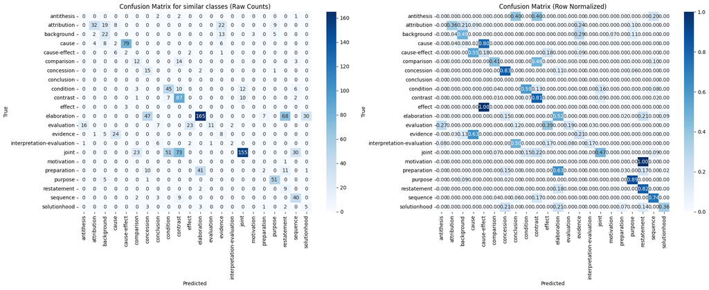

```python
y_true = similar_labels_df["correct_answer"].values
y_pred = similar_labels_df["answer"].values

# Calculate accuracy
accuracy = accuracy_score(y_true, y_pred)
print(f"Accuracy: {accuracy:.4f}")

# Get unique labels (relations)
labels = sorted(list(set(y_true) | set(y_pred)))

precision, recall, f1, _ = precision_recall_fscore_support(
    y_true, y_pred, average="macro", labels=labels
)
print(f"Macro Precision: {precision:.4f}")
print(f"Macro Recall: {recall:.4f}")
print(f"Macro F1: {f1:.4f}")

# Create figure with two subplots side by side
fig, (ax1, ax2) = plt.subplots(1, 2, figsize=(20, 8))

# 1. Regular confusion matrix
cm = confusion_matrix(y_true, y_pred, labels=labels)
sns.heatmap(
    cm,
    annot=True,
    fmt="d",
    cmap="Blues",
    xticklabels=labels,
    yticklabels=labels,
    ax=ax1,
)
ax1.set_xlabel("Predicted")
ax1.set_ylabel("True")
ax1.set_title("Confusion Matrix for similar classes (Raw Counts)")

# 2. Row-normalized confusion matrix (normalize by true label)
cm_normalized = confusion_matrix(y_true, y_pred, labels=labels, normalize="true")
sns.heatmap(
    cm_normalized,
    annot=True,
    fmt=".2f",
    cmap="Blues",
    xticklabels=labels,
    yticklabels=labels,
    ax=ax2,
)
ax2.set_xlabel("Predicted")
ax2.set_ylabel("True")
ax2.set_title("Confusion Matrix (Row Normalized)")

plt.tight_layout()
plt.savefig("confusion_matrices.png", dpi=300)
plt.show()
```

```python
cm_df = pd.DataFrame(cm_normalized, index=labels, columns=labels)

misclassifications = []

for true_class in labels:
    for pred_class in labels:
        if true_class != pred_class:
            raw_count = cm[labels.index(true_class), labels.index(pred_class)]

            # Only include pairs that actually appeared in the data
            if raw_count > 0:
                misclassifications.append(
                    {
                        "True Class": true_class,
                        "Predicted Class": pred_class,
                        "Error Rate": cm_df.loc[true_class, pred_class],
                        "Count": raw_count,
                    }
                )

misclass_df = pd.DataFrame(misclassifications)
misclass_df = misclass_df.sort_values(by="Error Rate", ascending=False)

print("Top confused pairs (by error rate):")
print(misclass_df.head(10))

misclass_df_by_count = misclass_df.sort_values(by="Count", ascending=False)
print("\nTop confused pairs (by raw count):")
print(misclass_df_by_count.head(10))
```

```
Top confused pairs (by error rate):
                   True Class Predicted Class  Error Rate  Count
30                     effect    cause-effect    1.000000      3
50                 motivation     restatement    1.000000      1
13                      cause    cause-effect    0.797980     79
41                   evidence           cause    0.631579     24
52                preparation     elaboration    0.630769     41
15               cause-effect           cause    0.545455      6
43  interpretation-evaluation      conclusion    0.500000      6
18                 comparison        contrast    0.482759     14
0                  antithesis      conclusion    0.400000      2
1                  antithesis        contrast    0.400000      2

Top confused pairs (by raw count):
     True Class Predicted Class  Error Rate  Count
13        cause    cause-effect    0.797980     79
48        joint        contrast    0.219880     73
33  elaboration     restatement    0.214511     68
47        joint       condition    0.153614     51
31  elaboration      concession    0.148265     47
52  preparation     elaboration    0.630769     41
34  elaboration    solutionhood    0.094637     30
49        joint        sequence    0.090361     30
41     evidence           cause    0.631579     24
37   evaluation          effect    0.389831     23
```

На этой confusion matrix мы видим большое количество отклонений от диагонали, а также самые частые "смешения" классов. Наиболее часто модель путает классы **cause** - **cause-effect**, **joint** - **contrast**. Также стоит отметить наличие совпадающих классов таких как **effect**, **cause** и **cause-effect**.

### Различные классы

```
Accuracy: 0.5904
Macro Precision: 0.5340
Macro Recall: 0.5801
Macro F1: 0.5071
```

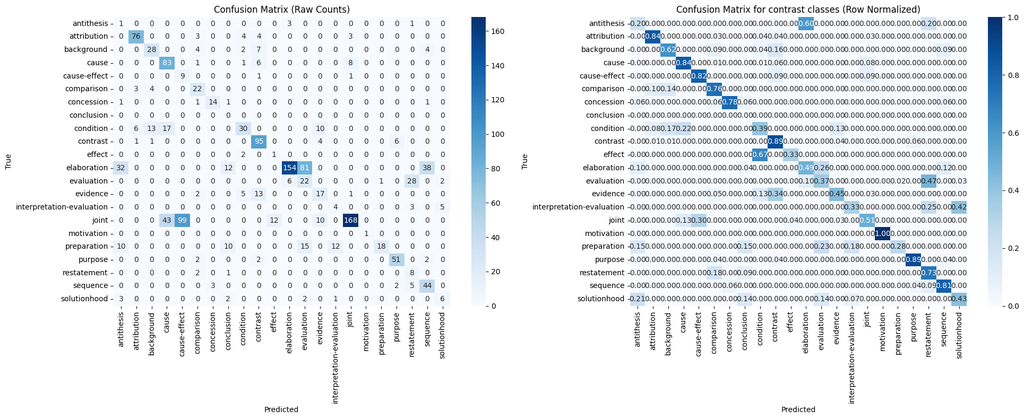

```python
y_true = different_labels_df["correct_answer"].values
y_pred = different_labels_df["answer"].values

# Calculate accuracy
accuracy = accuracy_score(y_true, y_pred)
print(f"Accuracy: {accuracy:.4f}")

# Get unique labels (relations)
labels = sorted(list(set(y_true) | set(y_pred)))

precision, recall, f1, _ = precision_recall_fscore_support(
    y_true, y_pred, average="macro", labels=labels
)
print(f"Macro Precision: {precision:.4f}")
print(f"Macro Recall: {recall:.4f}")
print(f"Macro F1: {f1:.4f}")

# Create figure with two subplots side by side
fig, (ax1, ax2) = plt.subplots(1, 2, figsize=(20, 8))

# 1. Regular confusion matrix
cm = confusion_matrix(y_true, y_pred, labels=labels)
sns.heatmap(
    cm,
    annot=True,
    fmt="d",
    cmap="Blues",
    xticklabels=labels,
    yticklabels=labels,
    ax=ax1,
)
ax1.set_xlabel("Predicted")
ax1.set_ylabel("True")
ax1.set_title("Confusion Matrix (Raw Counts)")

# 2. Row-normalized confusion matrix (normalize by true label)
cm_normalized = confusion_matrix(y_true, y_pred, labels=labels, normalize="true")
sns.heatmap(
    cm_normalized,
    annot=True,
    fmt=".2f",
    cmap="Blues",
    xticklabels=labels,
    yticklabels=labels,
    ax=ax2,
)
ax2.set_xlabel("Predicted")
ax2.set_ylabel("True")
ax2.set_title("Confusion Matrix for contrast classes (Row Normalized)")

plt.tight_layout()
plt.savefig("confusion_matrices.png", dpi=300)
plt.show()
```

```python
cm_df = pd.DataFrame(cm_normalized, index=labels, columns=labels)

misclassifications = []

for true_class in labels:
    for pred_class in labels:
        if true_class != pred_class:
            raw_count = cm[labels.index(true_class), labels.index(pred_class)]

            # Only include pairs that actually appeared in the data
            if raw_count > 0:
                misclassifications.append(
                    {
                        "True Class": true_class,
                        "Predicted Class": pred_class,
                        "Error Rate": cm_df.loc[true_class, pred_class],
                        "Count": raw_count,
                    }
                )

misclass_df = pd.DataFrame(misclassifications)
misclass_df = misclass_df.sort_values(by="Error Rate", ascending=False)

print("Top confused pairs (by error rate):")
print(misclass_df.head(10))

misclass_df_by_count = misclass_df.sort_values(by="Count", ascending=False)
print("\nTop confused pairs (by raw count):")
print(misclass_df_by_count.head(10))
```

```
Top confused pairs (by error rate):
                   True Class Predicted Class  Error Rate  Count
30                     effect       condition    0.666667      2
0                  antithesis     elaboration    0.600000      3
37                 evaluation     restatement    0.474576     28
44  interpretation-evaluation    solutionhood    0.416667      5
41                   evidence        contrast    0.342105     13
46                      joint    cause-effect    0.298193     99
33                elaboration      evaluation    0.255521     81
43  interpretation-evaluation     restatement    0.250000      3
51                preparation      evaluation    0.230769     15
24                  condition           cause    0.223684     17

Top confused pairs (by raw count):
     True Class Predicted Class  Error Rate  Count
46        joint    cause-effect    0.298193     99
33  elaboration      evaluation    0.255521     81
45        joint           cause    0.129518     43
34  elaboration        sequence    0.119874     38
31  elaboration      antithesis    0.100946     32
37   evaluation     restatement    0.474576     28
24    condition           cause    0.223684     17
51  preparation      evaluation    0.230769     15
23    condition      background    0.171053     13
41     evidence        contrast    0.342105     13
```